# Sequential Search

Pencarian data terkadang sangat diperlukan pada proses komputasi, sistem informasi, dan lain- lain. Dengan pencarian data ini maka data yang diperlukan dapat diketahui posisinya terhadap

kumpulan data yang lain, sehingga data ini dapat digunakan untuk proses berikutnya. Misalkan pada data mahasiswa, diperlukan data lengkap tentang mahasiswa dengan Nomor induk XXXXXX, maka diperlukan proses pencarian data tersebut dengan key berupa nomor induk mahasiswa. Data yang didapat ini dapat digunakan untuk keperluan yang lain, misalkan keperluan administratif.  
Pada umumnya, proses pencarian data ini menghasilkan posisi data yang dicari terhadap keseluruhan data, akan tetapi untuk pencarian data yang sederhana, nilai True atau False saja yang dihasilkan, nilai ini menandakan apakah data berada di sekumpulan data ataukah tidak. Proses pencarian sederhana ini sudah disediakan oleh python dengan menggunakan syntax in, seperti contoh berikut:

```python
a=[12,5,9,8,1,10,26]
11 in a
```

```
False
```

```python
12 in a
```

```
True
```

```python
15 in a
```

```
False
```

Algoritma searching yang pertama adalah sequential search.

Sequential Search merupakan teknik pencarian data dengan cara membandingkan data yang dicari dengan seluruh data yang terdapat pada kumpulan data secara satu persatu, mulai dari data pertama sampai dengan data terakhir. Ilustrasi sequential search ini dapat dilihat pada Gambar 1 berikut.

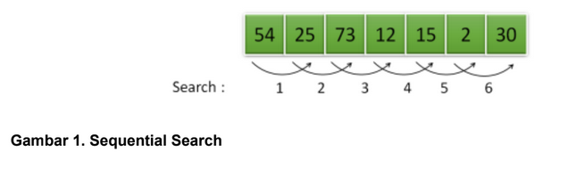

Terdapat dua konsep untuk sequential search berdasarkan kumpulan data yang akan dicari, yaitu  
1. Unordered List Sequential Search  
2. Ordered List Sequential Search

## Unordered List Sequential Search

Pada unordered list sequential search, data berada pada keadaan acak, tidak terurut, sehingga pencarian harus dilakukan mulai dari indeks awal sampai indeks terakhir dari data, atau pencarian berhenti ketika data sudah ditemukan

### Code

Berikut implementasi algoritma unordered list sequential search.

```python
def seqSearch(listData, data):
    ind = 0
    found = False
    while ind < len(listData) and not found:
        if listData[ind] == data:
            found = True
        else:
            ind = ind+1
    return found
```

```python
a=[12,5,9,8,1,10,26]
```

```python
seqSearch(a,1)
```

```
True
```

## Ordered List Sequential Search

Pada ordered list sequential search, data sudah dalam keadaan terurut, hal ini tentunya dapat mengurangi waktu komputasi pencarian. Ilustrasi algoritma pencarian ini, dapat dilihat pada Gambar 2 berikut:

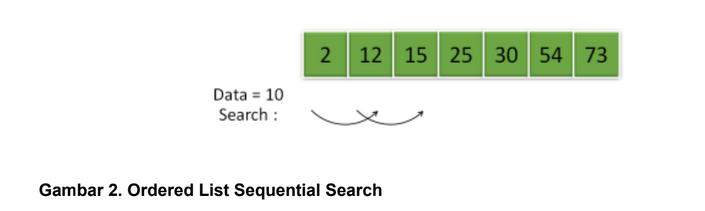

```python
def orderedSeqSearch(listData, data):
    ind = 0
    found = False
    stop = False
    position=[]
    while ind < len(listData) and not found and not stop:
        if listData[ind] == data:
            found = True
            position.append(ind)
        else:
            if listData[ind] > data:
                stop = True
            else:
                ind = ind+1
    if found:
        return ind
    else:
        return ('Data tidak ada')
```

```python
a=[1,1,5,5,5,8,9,10,12,26]
ind=orderedSeqSearch(a,5)
print(ind)
```

```
2
```

Pencarian dengan algoritma sequential search akan menemukan data dengan cepat jika data yang dicari terletak di indeks pertama dari suatu list data. Akan tetapi jika data yang dicari berada di posisi terakhir dari suatu list atau posisi lain, maka algoritma sequential search ini akan membutuhkan waktu yang lebih lama, karena algoritma ini akan mencari satu persatu, dimulai dari indeks pertama sampai dengan indeks terakhir.  
Pada algoritma binary search pencarian tidak dilakukan satu persatu, melainkan memanfaatkan kelebihan pencarian di data yang sudah terurut. Pada binary search, pencarian dilakukan pertama kali di indeks list yang berada ditengah. Jika data yang dicari sama dengan data pada indeks tersebut, maka pencarian berakhir. Akan tetapi jika data yang dicari lebih besar dari data yang berada di indeks tengah tersebuh, maka dilakukan pencarian lagi. Hanya saja pencarian tidak dilakukan pada seluruh data, hanya data yang berada indeks-indeks setelah indeks tengah tadi, karena data sebelum indeks tengah, pasti lebih kecil nilainya, sehingga tidak perlu dilakukan pencarian lagi. Proses ini dilakukan secara terus menerus sampai data ketemu atau tidak ada lagi data yang dapat dicari di dalam list. Oleh karena itu, binary search tidak perlu mencari di semua data pada list, sehingga waktu komputasi yang dibutuhkan lebih cepat dibandingkan dengan pencarian sequential search.  
Ilustrasi pencarian binary search ini dapat dilihat pada Gambar berikut.

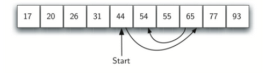

### Code

Berikut code untuk binary search dengan metode iteratif

```python
def binarySearch(listData, data):
    first = 0
    last = len(listData) - 1
    found = False
    while first <= last and not found:
        midpoint = (first + last) // 2
        if listData[midpoint] == data:
            found = True
        else:
            if data < listData[midpoint]:
                last = midpoint - 1
            else:
                first = midpoint + 1
    return found
```

```python
a=[4,6,10,34,56,78,99]
print(binarySearch(a,34))
```

```
True
```

### Code

Selain dengan model iteratif, algoritma binary search juga dapat ditulis secara rekursif, seperti yang ditunjukkan pada program berikut

```python
def binarySearch2(listData, data):
    if len(listData) == 0:
        return False
    else:
        midpoint = len(listData) // 2
        if listData[midpoint] == data:
            return True
        else:
            if data < listData[midpoint]:
                return binarySearch2(listData[first:last+1], data)
            else:
                return binarySearch2(listData[midpoint + 1:], data)
```

```python
a=[4,6,10,34,56,78,99]
binarySearch2(a,78)
```

```
True
```

# Hashing

Sequential Search mencari data dengan cara membandingkan data yang dicari dengan setiap data yang terdapat pada list satu persatu dari indeks awal sampai dengan indeks terakhir. Sedangkan pada binary search, list data dibagi menjadi dua buah grup, dan pencarian akan dilakukan dengan cara membandingkan data yang dicari dengan data yang terdapat pada indeks tengah, jika data yang dicari lebih besar terhadap data yang terdapat pada indeks tengah, maka pencarian berikutnya hanya dilakukan pada grup terakhir saja. Hal ini dilakukan terus menerus (pembagian list menjadi dua buah grup, pembandingan data yang dicari dengan nilai tengah), sampai data diketemukan, atau data tidak diketemukan. Oleh karena itu waktu komputasi yang dibutuhkan untuk binary search lebih sedikit dibandingkan dengan sequential search, karena pencarian tidak dilakukan pada setiap data, tapi hanya grup yang memenuhi syarat saja.  
Algoritma searching yang ketiga adalah Hashing. Penjelasan algoritma hashing ini akan dibagi menjadi tiga bagian, yaitu :  
1. Hashing  
2. Fungsi Hash  
3. Penanganan Collusion

### Hashing

Pencarian akan lebih cepat lagi jika semua data pada list terletak tepat berada ditempatnya masing-masing, sehingga pencarian dilakukan hanya dengan satu kali proses perbandingan saja. Algoritma ini dikenal dengan nama Hashing. Di dalam algoritma hashing ini terdapat beberapa istilah dasar sebagai berikut:

- Hash Table, yaitu sebuah tempat penyimpanan data, yang dibuat sedemikian rupa, sehingga dapat memudahkan pencarian. Tipe data list di python dapat digunakan untuk merepresentasikan hash table
- slot, yaitu posisi (indeks) yang terdapat pada hash table sebagai tempat penyimpanan setiap data. Karena slot berfungsi seperti halnya indeks, maka nilai slot adalah nilai integer mulai dari nol sampai dengan ukurang dari hash table, misalkan slot 0, slot 1, slot 2, .... , slot . Contoh hash table dan slot yang masih kosong dapat dilihat pada Gambar 1. Pada Gambar tersebut terdapat sebuah hash table dengan 11 slot kosong :

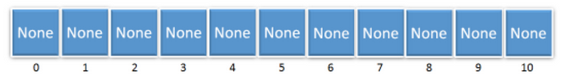

- Hash function, yaitu suatu fungsi yang memetakan antara data dengan slot di dalam hash table

### Fungsi Hash

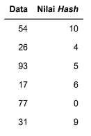

Sehingga dengan data dan nilai hash tersebut, maka representasi data di dalam hash table, dapat dilihat pada Gambar 2 berikut.

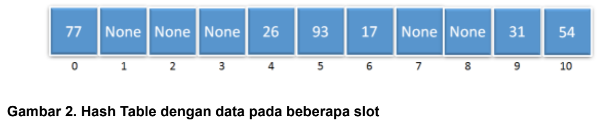

Setelah semua data berada di dalam hash table, maka dapat dihitung Load factor dari hash table, yang merupakan presentasi pemakaian hash tabel, dengan menggunakan persamaan  
λ = jumlahData/ukuranTabel  
Pencarian data dilakukan hanya dengan cara menghitung function hash berdasarkan data tersebut, dan nilai balik data tersebut merupakan index atau slot dari data di dalam list, kemudian dilakukan pengecekan keberadaan data tersebut hanya dengan satu kali perbandingan saja.

### Code

Berikut adalah fungsi-fungsi yang diperlukan untuk algoritma hashing ini, antara lain :

- hash function (gunakan remainder function, yaitu data dimodulus dengan 11), nilai balik merupakan nilai hash
- createHashTable, untuk membuat hash table, dengan inisialisasi semua slot berisi 'none'
- putData, yaitu menyusun data ke dalam hash table, berdasarkan nilai hash yang dihasilkan
- searchHash, argumen merupakan data yang dicari, dan nilai balik berupa True or False, yaitu apakah data ditemukan di dalam hash table

```python
def remainderFunction (data,num):
    return (data%num)
def createHashTable(num):
    temp=[]
    for i in range(num):
        temp.append('none')
    return(temp)
def putData(data,table):
    for i in range(len(data)):
        ind=remainderFunction(data[i],len(table))
        table[ind]=data[i]
    return(table)
def searchHash(data,table):
    hashVal=remainderFunction(data,len(table))
    if data==table[hashVal]:
        return True
    else:
        return False
```

```python
a=[54, 26, 93, 17, 77, 31]
hashTable=createHashTable(11)
print(hashTable)
```

```
['none', 'none', 'none', 'none', 'none', 'none', 'none', 'none', 'none', 'none', 'none']
```

```python
hashTable=putData(a,hashTable)
print(hashTable)
```

```
[77, 'none', 'none', 'none', 26, 93, 17, 'none', 'none', 31, 54]
```

```python
searchHash(93,hashTable)
```

```
True
```

### Fungsi Hash untuk String

Jika sebelumnya data yang digunakan adalah data dengan tipe integer, maka hash function juga dapat digunakan untuk data bertipe string. Nilai dari sebuah string dapat diambil dari jumlah nilai ascii karakter-karakter penyusun data string tersebut. Untuk mendapat nilai ascii dari suatu karakter, dapat menggunakan perintah ord. Berikut fungsi untuk mendapat nilai ascii dari suatu string.

### Code

```python
def strVal(strData):
    temp=0
    for i in range (len(strData)):
        temp=temp+ord(strData[i])
    return(temp)
```

```python
strVal('indonesia')
```

```
954
```

```python
print(strVal('dia'))
print(strVal('adi'))
```

```
302
302
```

Perfect Hash Function meminimalisir terjadinya colluision, akan tetapi terkadang, collusion ini tidak dapat dihindari, sehingga diperluka penanganan atau yang dikenal dengan collusion resolution.  
Penangan collusion ini dapat dilakukan dengan cara mencari kembali di dalam hash table slot yang kosong untuk data yang menyebabkan terjadinya collusion. Penanganan ini dikenal dengan konsep open addressing, yaitu pencarian slot kosong yang siap ditempati oleh data baru. Contoh penanganan collusion sederhana berdasarkan konsep open adressing ini adalah Linear Probing, yaitu mencari slot kosong dengan cara mengunjungi slot-slot ini satu persatu, dimulai dari slot tempat terjadinya collusion.

### Code

Misalkan terdapat data a=[54, 26, 93, 17, 77, 31], dan hash function yang digunakan adalah remainder function, maka tambahkan fungsi linear probing, agar dapat memasukkan data baru yaitu 44, 55, dan 20, sehingga a= [54, 26, 93, 17, 77, 31, 44, 55, 20]

```python
def linearProbing(ind,hashTable,data):
    count=ind
    found=False
    while (count!=ind-1) and not(found):
        if hashTable[count]=='none':
            found=True
            hashTable[count]=data
        else:
            count=count+1
            if count==len(hashTable)-1:
                count=0
    return(hashTable)
def putData3(a,hashTable,functionName):
    for i in range(len(a)):
        if functionName=='reminder':
            ind=remainderFunction(a[i],len(hashTable))
        elif functionName=='midSq':
            ind=midSqFunction(a[i],len(hashTable))

        if hashTable[ind]=='none':
            hashTable[ind]=a[i]
        else:
            hashTable=linearProbing(ind,hashTable,a[i])

    return(hashTable)
```

```python
a=[54, 26, 93, 17, 77, 31]
hashTable=createHashTable(11)
print(hashTable)
hashTable=putData3(a,hashTable,'reminder')
print(hashTable)
```

```
['none', 'none', 'none', 'none', 'none', 'none', 'none', 'none', 'none', 'none', 'none']
[77, 'none', 'none', 'none', 26, 93, 17, 'none', 'none', 31, 54]
```

```python
a=[54, 26, 93, 17, 77, 31,44,55,20]
hashTable=createHashTable(11)
print(hashTable)
hashTable=putData3(a,hashTable,'reminder')
print(hashTable)
```

```
['none', 'none', 'none', 'none', 'none', 'none', 'none', 'none', 'none', 'none', 'none']
[77, 44, 55, 20, 26, 93, 17, 'none', 'none', 31, 54]
```

Jika pada Linear Probing, penempatan data dilakukan dengan cara mencari satu persatu slot kosong dari posisi terjadinya collusion, maka quadratic probing, yaitu data collusion diletakkan dengan cara menambahkan posisi collusion dengan nilai sebagai berikut : 1, 3, 5, 7, 9, ... Contoh quadratic probing dapat dilihat pada Gambar berikut :

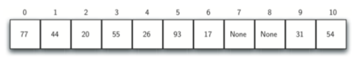

Metode lain untuk penanganan collusion ini adalah Chaining, dengan chaining ini, satu slot dapat ditempati oleh beberapa data sekaligus. Untuk proses pencarian dilakukan pada slot tersebut. Contoh chaining ini dapat dilihat pada Gambar berikut

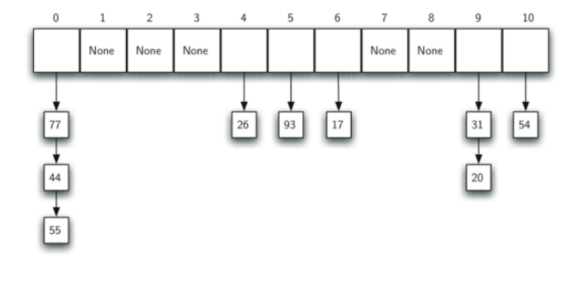

# 1. Close Address (Chaining)--> CRU(cari diganti dengan yang baru)D(cari di delete)

```python
def createChaining(size):
    return [[] for _ in range(size)]

def hasing(key, size):
    return key % size

def Cari(Chaining, key, size):
    index = hasing(key, size)
    Chaining[index].append(key)

def search(Chaining, key, size):
    index = hasing(key, size)
    if key in Chaining[index]:
        return index
    return -1

def update(Chaining, old, new, size):
    index = hasing(old, size)
    if old in Chaining[index]:
        Chaining[index].remove(old)
        Cari(Chaining, new, size)
        return True
    return False

def delete(Chaining, key, size):
    index = hasing(key, size)
    if key in Chaining[index]:
        Chaining[index].remove(key)
        return True
    return False
```

```python
size = 10
table = createChaining(size)

Cari(table, 15, size)
Cari(table, 25, size)
Cari(table, 35, size)

print("Awal:", table)
update(table, 25, 50, size) #mengganti
print("Setelah update:", table)
delete(table, 35, size) #menghapus
print("Setelah delete:", table)
```

```
Awal: [[], [], [], [], [], [15, 25, 35], [], [], [], []]
Setelah update: [[50], [], [], [], [], [15, 35], [], [], [], []]
Setelah delete: [[50], [], [], [], [], [15], [], [], [], []]
```

# 2. Open Address (Linear Probbing) --> CRUD

```python
# untuk menghitung isi tabel agar tahu kapan penuh
def hitung_isi(table):
    jumlah = 0
    for item in table:
        # Menghitung laci yang ada isinya (bukan None dan bukan bekas dihapus)
        if item is not None and item != "DELETED":
            jumlah += 1
    return jumlah

def create_table(size):
    return [None] * size

# Fungsi Hash 1: Biasa (Sisa Bagi / Modulo)
def hash_function(key, size):
    return key % size

# Fungsi Hash 2: Mid-Square (Sesuai file kamu)
def mid_square_hash(key, size):
    square = key * key
    s = str(square)
    mid = len(s) // 2
    if len(s) % 2 == 0:
        middle = s[mid-1:mid+1]
    else:
        middle = s[mid]
    return int(middle) % size

# --- CRUD LINEAR PROBING ---

def insert(table, key, size, jenis_hash="biasa"):
    # CEK TABEL PENUH: Jika jumlah isi sudah sama dengan ukuran tabel, tolak!
    if hitung_isi(table) == size:
        print(f"[EROR] Tabel sudah penuh! Angka {key} tidak bisa masuk.")
        return

    # Pilih mau pakai rumus hash yang mana
    if jenis_hash == "biasa":
        index = hash_function(key, size)
    else:
        index = mid_square_hash(key, size)

    # Selama lacinya masih ada isinya, geser terus ke kanan (+1)
    while table[index] is not None and table[index] != "DELETED":
        index = (index + 1) % size

    table[index] = key

def search(table, key, size, jenis_hash="biasa"):
    if jenis_hash == "biasa":
        index = hash_function(key, size)
    else:
        index = mid_square_hash(key, size)

    start = index
    while table[index] is not None:
        if table[index] == key:
            return index
        index = (index + 1) % size
        if index == start:
            break
    return -1

def update(table, old, new, size, jenis_hash="biasa"):
    idx = search(table, old, size, jenis_hash)
    if idx != -1:
        table[idx] = new
        return True
    return False

def delete(table, key, size, jenis_hash="biasa"):
    idx = search(table, key, size, jenis_hash)
    if idx != -1:
        # Diubah jadi None agar tidak merusak antrean saat digeser
        table[idx] = None
        return True
    return False
```

```python
size = 10
table = create_table(size)

print("--- Memasukkan 10 Data (Sampai Penuh) ---")
daftar_angka = [10, 20, 30, 40, 50, 60, 70, 80, 90, 100]

for angka in daftar_angka:
    insert(table, angka, size, "biasa")

print("\nIsi tabel Awal (Sudah Penuh 10/10):", table)

print("\n--- Memasukkan Data ke-11 (Jika Penuh) ---")
insert(table, 110, size, "biasa")

print("\n--- Lanjut Update dan Delete ---")
update(table, 20, 99, size, "biasa")
print("Setelah update 20 jadi 99:", table)

delete(table, 10, size, "biasa")
print("Setelah delete angka 10:", table)

print("\n--- Memasukkan Data Baru Setelah Ada yang Dihapus ---")
insert(table, 110, size, "biasa")
print("Isi tabel Akhir:", table)
```

```
--- Memasukkan 10 Data (Sampai Penuh) ---

Isi tabel Awal (Sudah Penuh 10/10): [10, 20, 30, 40, 50, 60, 70, 80, 90, 100]

--- Memasukkan Data ke-11 (Jika Penuh) ---
[EROR] Tabel sudah penuh! Angka 110 tidak bisa masuk.

--- Lanjut Update dan Delete ---
Setelah update 20 jadi 99: [10, 99, 30, 40, 50, 60, 70, 80, 90, 100]
Setelah delete angka 10: [None, 99, 30, 40, 50, 60, 70, 80, 90, 100]

--- Memasukkan Data Baru Setelah Ada yang Dihapus ---
Isi tabel Akhir: [110, 99, 30, 40, 50, 60, 70, 80, 90, 100]
```

# 2. Open Address (Quadratic Probing) --> CRUD

```python
# (Fungsi hitung_isi, create_table, hash_function, dan mid_square_hash
# tidak perlu ditulis ulang jika sudah dijalankan di cell atasnya)

def insert(table, key, size, jenis_hash="biasa"):
    # CEK TABEL PENUH
    if hitung_isi(table) == size:
        print(f"[EROR] Tabel sudah penuh! Angka {key} tidak bisa masuk.")
        return

    if jenis_hash == "biasa":
        index = hash_function(key, size)
    else:
        index = mid_square_hash(key, size)

    i = 0
    # Selama laci penuh, lompat sejauh i pangkat 2 (i*i)
    while table[(index + i*i) % size] is not None and table[(index + i*i) % size] != "DELETED":
        i += 1
        if i == size: # Mencegah muter-muter error
            break

    table[(index + i*i) % size] = key

def search(table, key, size, jenis_hash="biasa"):
    if jenis_hash == "biasa":
        index = hash_function(key, size)
    else:
        index = mid_square_hash(key, size)

    i = 0
    while table[(index + i*i) % size] is not None:
        if table[(index + i*i) % size] == key:
            return (index + i*i) % size
        i += 1
        if i == size:
            break
    return -1

def update(table, old, new, size, jenis_hash="biasa"):
    idx = search(table, old, size, jenis_hash)
    if idx != -1:
        table[idx] = new
        return True
    return False

def delete(table, key, size, jenis_hash="biasa"):
    idx = search(table, key, size, jenis_hash)
    if idx != -1:
        table[idx] = None
        return True
    return False
```

```python
size = 10
table = create_table(size)

print("--- Memasukkan 10 Data ke Quadratic Probing ---")

daftar_angka = [11, 21, 31, 41, 51, 61, 71, 81, 91, 101]

for key in daftar_angka:
    insert(table, key, size, "mid_square")

print("\nIsi tabel Awal (Penuh 10/10):", table)

# 2. Pembuktian saat Slot Penuh
print("\n--- Mencoba data ke-11 (Harusnya EROR) ---")
insert(table, 111, size, "mid_square")

# 3. Update dan Delete
print("\n--- Update dan Delete ---")
update(table, 21, 999, size, "mid_square")
print("Setelah update 21 jadi 999:", table)

delete(table, 11, size, "mid_square")
print("Setelah delete angka 11:", table)
```

```
--- Memasukkan 10 Data ke Quadratic Probing ---

Isi tabel Awal (Penuh 10/10): [51, 101, 11, 61, 21, 71, 31, 81, 41, 91]

--- Mencoba data ke-11 (Harusnya EROR) ---
[EROR] Tabel sudah penuh! Angka 111 tidak bisa masuk.

--- Update dan Delete ---
Setelah update 21 jadi 999: [51, 101, 11, 61, 999, 71, 31, 81, 41, 91]
Setelah delete angka 11: [51, 101, None, 61, 999, 71, 31, 81, 41, 91]
```

# 3. MidSquareMethod(Function Hash)

```python
def mid_square_hash(key, size):
    square = key * key
    s = str(square)

    mid = len(s) // 2
    if len(s) % 2 == 0:
        middle = s[mid-1:mid+1]
    else:
        middle = s[mid]

    return int(middle) % size
```

```python
# ===== MAIN =====
size = 10
keys = [12, 25, 44, 31]

for k in keys:
    print(f"Key {k} -> index {mid_square_hash(k, size)}")
```

```
Key 12 -> index 4
Key 25 -> index 2
Key 44 -> index 3
Key 31 -> index 6
```